# MSB7102 Mini-project, Semester I, 2021

Christopher Lubega 2020/HD07/22162U

# Results

A total of 777 participants were recruited for the study, of whom most (53.0%) were female. Mean age at the point of sample collection was 483 days (sd=295), approximately 1 year and 4 months. Majority of the participants ( 91.5%) had vaginal birth while the rest (8.5%) were born through cesarean section. 260 participants (33.4%) developed diabetes, of whom most (54.6%) were female, and were all (100%) born through vaginal birth.

Table 1: Clinical and demographic characteristics of study participants

```r
# Compute p-values for significance of association between each of the other variables and disease status
pvalue <- function(x, ...) {
  y <- unlist(x)
  if (is.numeric(y)) {
    p <- t.test(info$Age_at_Collection~info$Case_Control)$p.value
  } else if(y[1]=="female"){
    p <- fisher.test(info$Case_Control, info$Gender)$p.value
  }else
    p <- fisher.test(info$Case_Control, info$Delivery_Route)$p.value
  c("", sub("<", "&lt;", format.pval(p, digits=4, eps=0.05)))
}
# Tabulate summary statistics by disease status

table1(~ Gender + Delivery_Route + Age_at_Collection | Case_Control, data= info, extra.col=list(`P-value`=pvalue))
```

|  | case (N=260) | control (N=517) | Overall (N=777) | P-value |
| --- | --- | --- | --- | --- |
| Gender |  |  |  |  |
| female | 142 (54.6%) | 270 (52.2%) | 412 (53.0%) | 0.543 |
| male | 118 (45.4%) | 247 (47.8%) | 365 (47.0%) |  |
| Delivery_Route |  |  |  |  |
| cesarian | 0 (0%) | 66.0 (12.8%) | 66.0 (8.5%) | < 0.05 |
| vaginal | 260 (100%) | 451 (87.2%) | 711 (91.5%) |  |
| Age_at_Collection |  |  |  |  |
| Mean (SD) | 498 (302) | 475 (291) | 483 (295) | 0.3085 |
| Median [Min, Max] | 474 [30.0, 1100] | 443 [6.00, 1230] | 452 [6.00, 1230] |  |

### Graphical Representations

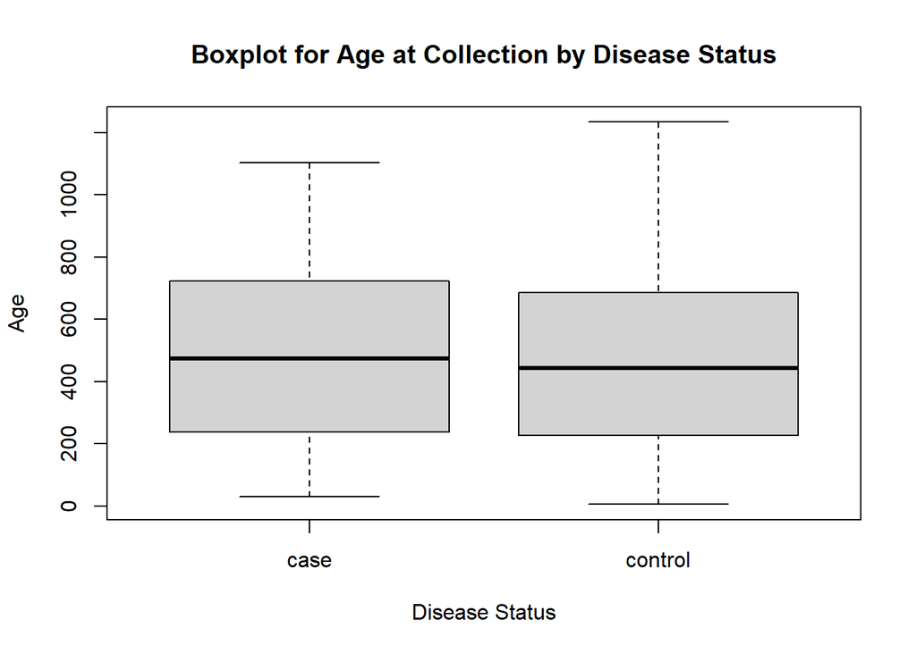

```r
boxplot(info$Age_at_Collection~ info$Case_Control, main="Boxplot for Age at Collection by Disease Status", xlab="Disease Status",
        ylab="Age")
```

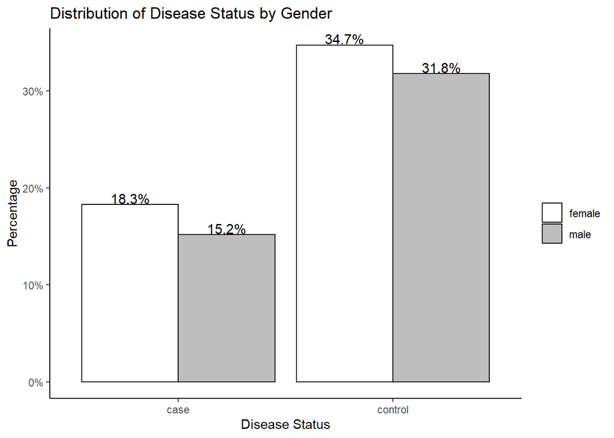

```r
ggplot(info, aes(x =Case_Control ,y= (..count..)/sum(..count..), fill= Gender)) +
  geom_bar(position = "dodge", color= "Black")+
  scale_y_continuous(labels=scales::percent)+
  labs(title = "Distribution of Disease Status by Gender",
       y= "Percentage", x= "Disease Status" )+
  geom_text(stat= "count", aes(label= scales::percent((..count..)/sum(..count..))), position = position_dodge(0.9), size=4, vjust=-0.1)+
  theme_classic()+
  scale_fill_manual(name = "", values = c("White", "grey"))
```